# Cardio_Fitness_Analysis

```python
# Loading required libraries
import matplotlib.pyplot as plt
import seaborn as sns
import pandas as pd
import numpy as np
```

```python
# Loading dataset into dataframe
cardio_df = pd.read_csv('CardioGoodFitness.csv')
```

```python
# Printing top entries of the cardio dataset
cardio_df.head()
```

|  | Product | Age | Gender | Education | MaritalStatus | Usage | Fitness | Income | Miles |
| --- | --- | --- | --- | --- | --- | --- | --- | --- | --- |
| 0 | TM195 | 18 | Male | 14 | Single | 3 | 4 | 29562 | 112 |
| 1 | TM195 | 19 | Male | 15 | Single | 2 | 3 | 31836 | 75 |
| 2 | TM195 | 19 | Female | 14 | Partnered | 4 | 3 | 30699 | 66 |
| 3 | TM195 | 19 | Male | 12 | Single | 3 | 3 | 32973 | 85 |
| 4 | TM195 | 20 | Male | 13 | Partnered | 4 | 2 | 35247 | 47 |

```python
# Shape of dataset in rows and columns format
print(cardio_df.shape)
```

```
(180, 9)
```

```python
# Information about dataset including datatypes and missing values
cardio_df.info()
```

```
<class 'pandas.core.frame.DataFrame'>
RangeIndex: 180 entries, 0 to 179
Data columns (total 9 columns):
 #   Column         Non-Null Count  Dtype
---  ------         --------------  -----
 0   Product        180 non-null    object
 1   Age            180 non-null    int64
 2   Gender         180 non-null    object
 3   Education      180 non-null    int64
 4   MaritalStatus  180 non-null    object
 5   Usage          180 non-null    int64
 6   Fitness        180 non-null    int64
 7   Income         180 non-null    int64
 8   Miles          180 non-null    int64
dtypes: int64(6), object(3)
memory usage: 12.8+ KB
```

```python
# Total of missing values per column
cardio_df.isna().sum()
```

```
Product          0
Age              0
Gender           0
Education        0
MaritalStatus    0
Usage            0
Fitness          0
Income           0
Miles            0
dtype: int64
```

###### Insight

From the above info function's output and missingg value function, we can conclude that the cardio dataset has no missing values present.

```python
# Stistical summary of numeric data including mean, median and std deviation for all the columns
cardio_df.describe()
```

|  | Age | Education | Usage | Fitness | Income | Miles |
| --- | --- | --- | --- | --- | --- | --- |
| count | 180.000000 | 180.000000 | 180.000000 | 180.000000 | 180.000000 | 180.000000 |
| mean | 28.788889 | 15.572222 | 3.455556 | 3.311111 | 53719.577778 | 103.194444 |
| std | 6.943498 | 1.617055 | 1.084797 | 0.958869 | 16506.684226 | 51.863605 |
| min | 18.000000 | 12.000000 | 2.000000 | 1.000000 | 29562.000000 | 21.000000 |
| 25% | 24.000000 | 14.000000 | 3.000000 | 3.000000 | 44058.750000 | 66.000000 |
| 50% | 26.000000 | 16.000000 | 3.000000 | 3.000000 | 50596.500000 | 94.000000 |
| 75% | 33.000000 | 16.000000 | 4.000000 | 4.000000 | 58668.000000 | 114.750000 |
| max | 50.000000 | 21.000000 | 7.000000 | 5.000000 | 104581.000000 | 360.000000 |

###### Insights and Recommendations

1. The sample dataset has customers from age 18 to 50 years old with mean age of 28 years and median age of 26years.
2. The customers have average ncome of 53.7k ranging from around 30k to 105k per year.
3. A customer wants to run 103 miles on average.

## Visualizations and tables

##### Univariate Analysis

```
TM195    80
TM498    60
TM798    40
Name: Product, dtype: int64
```

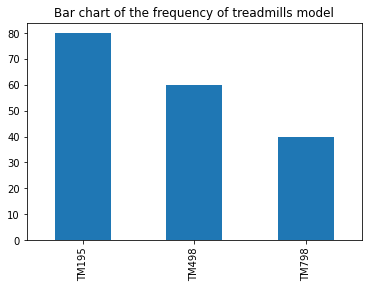

```python
# Unique Product count in the dataset
tb=cardio_df['Product'].value_counts()
print(tb)
ax = tb.plot(kind='bar')
ax.set_title('Bar chart of the frequency of treadmills model')
plt.show()
```

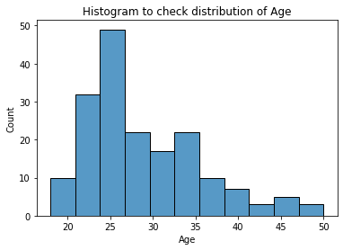

```python
# Histogram of variable Age
ax = sns.histplot(x = 'Age',  data=cardio_df)
ax.set_title('Histogram to check distribution of Age')
plt.show()
```

The age of customers follows a Right-tailed Normal distriution curve with the mean score of 28.8 and standard deviation of 6.94.

```
Male      104
Female     76
Name: Gender, dtype: int64
```

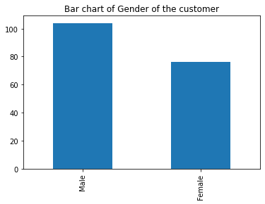

```python
# Table and bar chart of variable Gender
tb=cardio_df['Gender'].value_counts()
print(tb)
ax = tb.plot(kind='bar')
ax.set_title('Bar chart of Gender of the customer')
plt.show()
```

Sample consists of 104 males and 76 females.

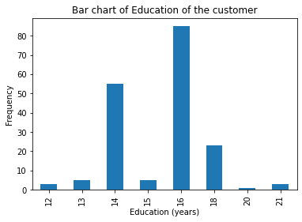

```python
# Bar chart of variable Education
ax = cardio_df['Education'].value_counts(sort=False).plot(kind='bar')
ax.set_title('Bar chart of Education of the customer')
ax.set(xlabel='Education (years)', ylabel='Frequency')
plt.show()
```

###### Insights

Most of the customers has 14 or 16 years of education experience. We can conclude that most of the customers are graduates and undergraduates.

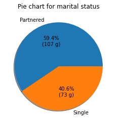

```python
# Plotting a pie chart for marital status

# Frequency table of marital status
marital_table = cardio_df['MaritalStatus'].value_counts()

# Function to calculate percentage of population for labeling
def func(pct, allvals):
    absolute = int(round(pct/100.*np.sum(allvals)))
    return "{:.1f}%\n({:d} g)".format(pct, absolute)

# Plotting pie chart using matplotlib
plt.pie(marital_table,
        labels = marital_table.index,
        autopct=lambda pct: func(pct, marital_table),
        shadow=True)
plt.title("Pie chart for marital status")
plt.show()
```

###### Insight

The pie chart shows the population demographic of customers with their marital status.

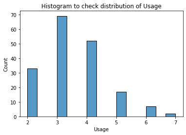

```python
# Histogram of Avg. no of times the customer wants to use the treadmill every week
ax = sns.histplot(x = 'Usage', data=cardio_df)
ax.set_title('Histogram to check distribution of Usage')
plt.show()
```

###### Insights and Recommendations

1. Mostly customers wants to use treadmill 3-4 times in a week. A daywise machine usage can be calculated to optimise the usage of machines for these customers by collecting their preference data.
2. Very few people wants to use treadmill everyday.

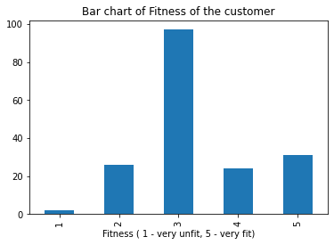

```python
# Frequency bar chart of self-rated fitness score of the customer
ax = cardio_df['Fitness'].value_counts(sort=False).plot(kind='bar')
ax.set_title('Bar chart of Fitness of the customer')
ax.set(xlabel='Fitness ( 1 - very unfit, 5 - very fit)')
plt.show()
```

###### Insights

Most of the people consider themselves average fit and very few consider very unfit.

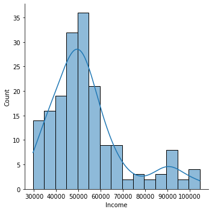

```python
# Histogram of income of the customer
ax=sns.displot(cardio_df['Income'], kde=True)
plt.show()
```

###### Insights

The customers have average income of around 50k ranging from around 30k to 105k per year. The distribution is right tailed and many people comes in high range salary.

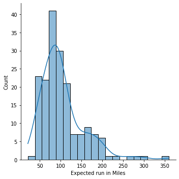

```python
# Histogram of distance in miles that a customer expects to run
ax=sns.displot(cardio_df['Miles'], kde=True)
ax.set_axis_labels('Expected run in Miles')
plt.show()
```

###### Insights

Most of the sample population of customers expects to run 103 miles on average, and some of them have a target of of more than 200 miles, twice of average customers.

##### Bivariate Analysis

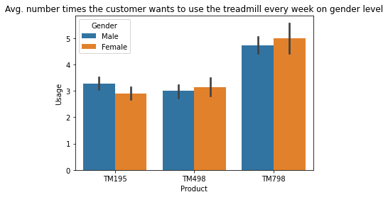

```python
# Bar chart of Usage for each product gender wise
ax = sns.barplot(x = "Product", y = 'Usage', hue = 'Gender', data=cardio_df)
ax.set_title('Avg. number times the customer wants to use the treadmill every week on gender level')
plt.show()
```

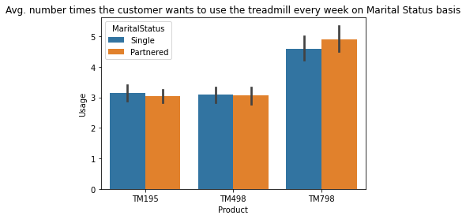

```python
# Bar chart of Usage for each product on Marital Status
ax = sns.barplot(x = "Product", y = 'Usage', hue = 'MaritalStatus', data=cardio_df)
ax.set_title('Avg. number times the customer wants to use the treadmill every week on Marital Status basis')
plt.show()
```

###### Insights

No special prefernces can be seen for single or partnered people for treadmills.

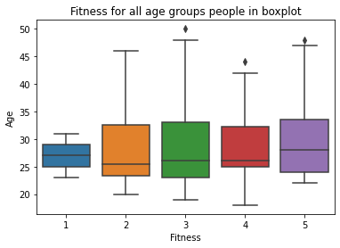

```python
# Boxplot of Fitness for all age groups people
ax = sns.boxplot(x = "Fitness", y = 'Age', data=cardio_df)
ax.set_title('Fitness for all age groups people in boxplot')
plt.show()
```

###### Insights

Young people from age 25-30 years old rated themselves highly unfit compared to higher age group. Their defination of fitness might be different from higher age group people.

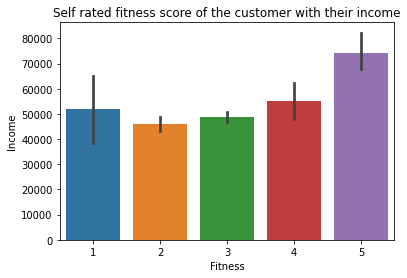

```python
# Bar chart of Fitness and incomes of customers
ax = sns.barplot(x = "Fitness", y = 'Income',data=cardio_df)
ax.set_title('Self rated fitness score of the customer with their income')
plt.show()
```

###### Insights

People with high income have rated themsevles highly fit.

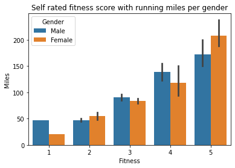

```python
# Bar chart of Fitness with running miles per gender
ax = sns.barplot(x = "Fitness", y = 'Miles',hue = 'Gender',data=cardio_df)
ax.set_title('Self rated fitness score with running miles per gender')
plt.show()
```

###### Insights and recommendations

1. Higher the fitness on self-fitness scale, higher the number of miles a person wants to run and use treadmill.
2. Self-rated highly fit women expects to run more than 200 miles, whereas males don't want to run more than 170 miles.
3. Females who have rated themselves highly unfit, don't want to run on treadmill. We can further investigate into this more with more data about their fitness goal.

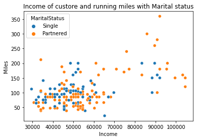

```python
# Scatterplot of income and running miles of customer coloured with marital status
ax=sns.scatterplot(x='Income', y='Miles', hue='MaritalStatus', data=cardio_df)
ax.set_title("Income of custore and running miles with Marital status")
plt.show()
```

###### Insights

Couples with high income expects to run more miles compared to singles.

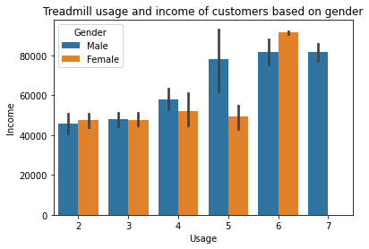

```python
# Bar chart of treadmill usage and income of customers based on gender
ax = sns.barplot(x = "Usage", y = 'Income', hue = 'Gender', data=cardio_df)
ax.set_title('Treadmill usage and income of customers based on gender')
plt.show()
```